# rOceans

# Functions for accessing and exploring environmental drivers of marine biodiversity

## Function #6 *oceanEnv*

Allows accessing environmental layers at present conditions to explore and test potential drivers of marine biodiversity patterns

Following with the previous example on abundance and diversity of Acropora species

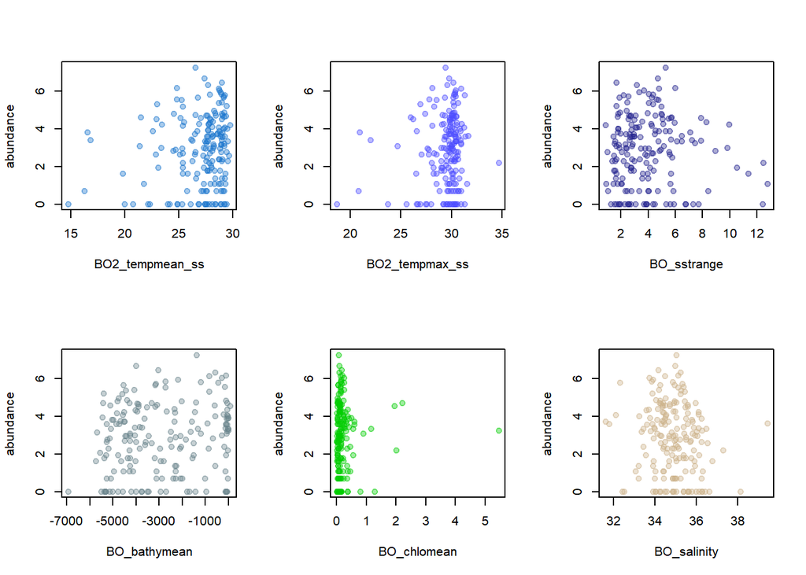

```r
Acropora_abundance = oceanAbundGrid(occurrences = Acropora_Total_Checked, cell_size=5)

# getting envioronmental parameters and linking them to biodiversity patterns
abundance_environ_df = invisible(oceanEnv(biod_grid = Acropora_abundance,
                       biodiv_metric = "abundance",
                       plot=T,
                       log_scale=T))
```

We can also explore environmental drivers of other metrics such as species richness using previously computed grids

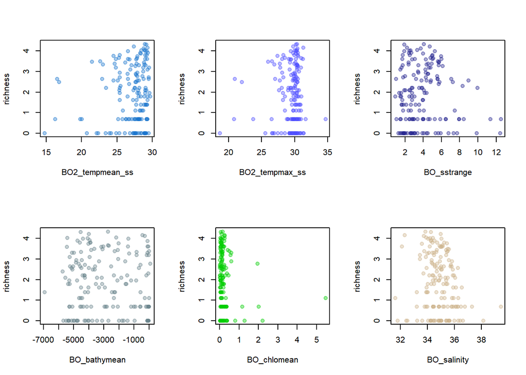

```r
abundance_environ_df = invisible(oceanEnv(biod_grid = Acropora_richness,
                       biodiv_metric = "richness",
                       plot=T,
                       log_scale=T))
```

We can specify any alternative environmental parameters using env_parameters to see the full list of avilable parameters (326)

```r
env_variables = sdmpredictors::list_layers()
marine_layers = env_variables[env_variables$marine==T, ]
```

## Function #7 *oceanFuture*

Allows accessing, analyzing and mapping future trends in temeperature and other environmental parameters according to different IPCC scenarios

In the following example, we will access and map expected increases in Sea Surface Temperature data for 2100 according to different IPCC scenarios

```r
SST_2100_RCP8.5 = oceanFuture(IPCC_scenario = "RCP85")
```

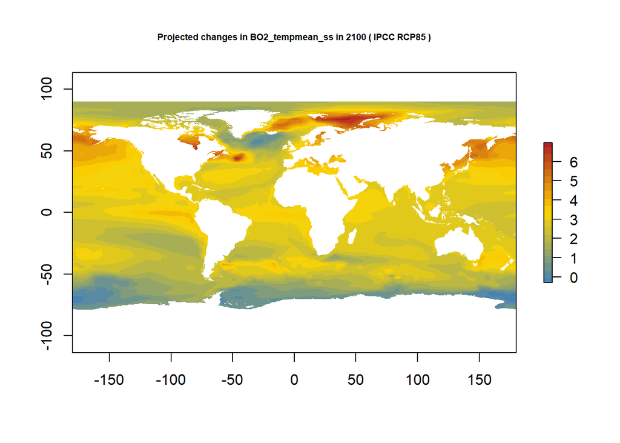

```r
SST_2100_RCP4.5 = oceanFuture(IPCC_scenario = "RCP45")
```

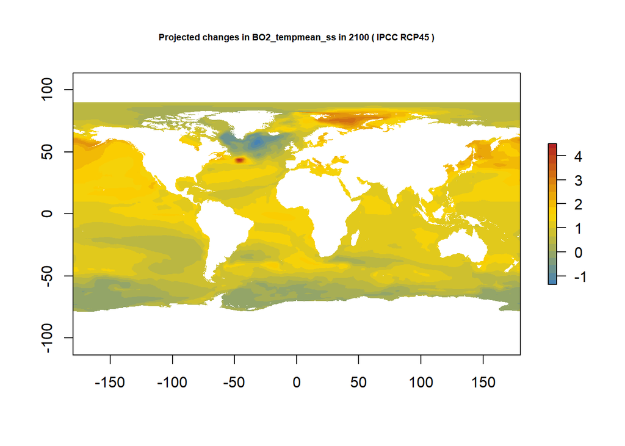

```r
SST_2100_RCP2.5 = oceanFuture(IPCC_scenario = "RCP26")
```

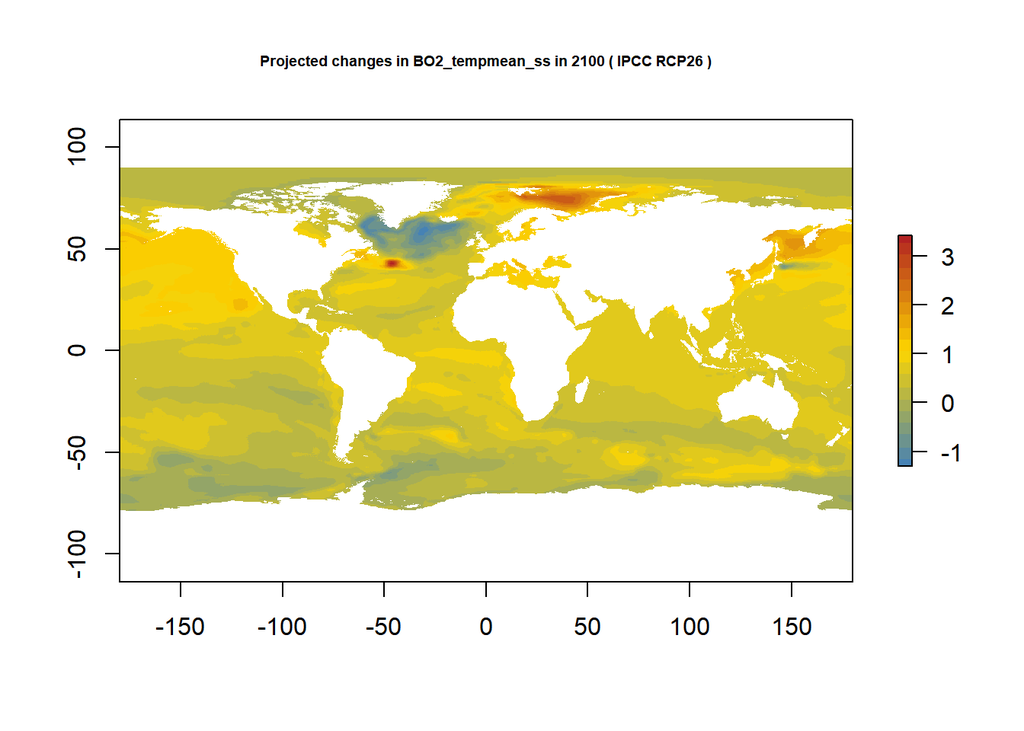

You can check other available enviornmental parameters with avaialable future projections

```r
env_variables_future = sdmpredictors::list_layers_future()
```